# Explore how the household composition varies across ethnic groups in Britain.

Felix Brett. Student ID: 670023688

27/04/2020

Link to Github Repository: https://github.com/FelixBrett/Final-Report

Single-parenthood is a particularly interesting type of household composition because it is traditionally indicative of hardship. People living in single parent households are more likely to be disabled (both parents and children); they’re more likely to report psychological distress and in 2015, 20% of single parents lived in persistent poverty compared to only around 5% of coupled parents [Rabindrakumar 2018:10]. The relationship between single parenthood rates and race is thus important both because it can be very debilitating for families and because it appears to impact some races significantly more than others. In this report, I hypothesise that race is the most important independent variable available for explaining single parenthood rates. Hence I examine the effect of monthly pay on each race’s propensity to be single parents as well as immigration status. These two variables represent socio-economic conditions which vary significantly across races and which could act as better independent variables for explaining higher single parenthood rates in Black people (i.e that high single parenthood rates in Black people are due to their low average monthly pay or the fact that most are immigrants). However I hypothesised to begin with that being Black is the best explanatory variable, because if lower monthly pay or being an immigrant could explain higher single parenthood rates than the other non-White ethnicities would follow Black people and also display higher single parenthood rates compared to White people.

It is important to clarify that because of the way the data is coded, my assertion is that Black individuals are more likely than other races to live in single parent households. As opposed to being that Black people are more likely to be raised in single parent households or that Black people are more likely to be single parents. This clarification is important as I decided to use individual data rather than household data. Household data doesn’t take into account the complexities made possible by the existence of multi-ethnic households. It would be inaccurate to label the entire household with the ethnicity of only one of the household’s members. Therefore my project began by subsetting each individual in to a type of household and a race so that each race’s propensity to live in a certain type of household could be calculated. However a major problem occured in that ethnicities with a tendency to have more children then appeared to have higher single-parenthood rates, because children and young people in single parent households would then act to increase the single parenthood rate.

To solve this problem I’ve had to remove all households where not all members of the family are of the same race. This is a huge limitation because it means that the growing significance of multi-ethnic households is being ignored. But it is necessary to ensure that race is the independent variable in the study.

I began the project by mutating the data so that ethnicities are clearly labelled and the household types are simplified into groups. This simplicity also means that the different kinds of household match typical British social units such as the single-parent household and the nuclear family. The household types are:

1 = 1 adult

2 = 1 adult with 1+ children (who I will refer to as single parent households)

3 = 2 adults and no children

4 = 2 adults and 1+ children

5 = 3+ adults and no children

6 = 3+ adults and children

The household types were going to be labelled (respectively) : lives alone, single parent, couple with no children, couple with children, cohabiting adults and cohabiting adults with children but then I realised that the dataset doesn’t actually verify the type of family. For example, two adults living together with children aren’t necessarilly a couple and they therefore don’t necessarilly constitute a nuclear family. Whereas a group of cohabiting adults could actually be a married couple living with their adult children. Therefore some groups of adults living together may actually constitute a nuclear family. After establishing the different household types, race was tabulated against household type. This was done with the aid of a package called crosstab which helped in producing a simple tabulation of the survey data.

```
##                            household_type      1      2      3      4      5      6    Sum
## race
## White_British                              17.57   4.15  33.29  21.47  15.86   7.66 100.00
## Irish                                      22.34   4.62  25.19  22.93  15.15   9.76 100.00
## Indian                                      6.47   2.33  15.44  31.41  23.17  21.17 100.00
## Pakistani                                   3.88   3.93   5.69  37.01  14.08  35.41 100.00
## Bangladeshi                                 2.90   3.34   3.51  38.66  12.48  39.10 100.00
## Chinese                                    17.79   1.51  22.40  28.78  24.92   4.61 100.00
## Black_Caribbean                            26.33  14.04  12.49  14.90  19.71  12.54 100.00
## Black_African                              12.72  15.32   6.34  30.31  16.89  18.42 100.00
## Any_other_white_background                 13.84   4.32  24.80  35.78  14.14   7.11 100.00
## Other                                      13.87   7.93  14.11  31.10  17.17  15.83 100.00
```

Looking at the column marked ‘2’ we can see that Black people (both African and Caribbean) are significantly more likely to be single parents than the other ethnic groups. There are other salient differences between the ethnicities, such as that Bangladeshi people are both the most likely to live in very large families and the least likely to live alone. This project explores the first finding, because there are a lot of different ways in which 3+ adults and 1+ children can live together, thus we can’t label this household type as any particular kind of family. Whereas we can deduce that the vast majority of households with 1 adult and 1+ children are a single parent with their child or children. Cases wherein the child isn’t actually related to the adult taking care of them will also reflect the same socio-economic conditions as if they were related and thus this will still be treated as a single-parent households.

But before examining the other variables beside race, it’s important to check whether high single parenthood rates in Black people are consistent throughout the waves of the dataset or whether there are anomalies.

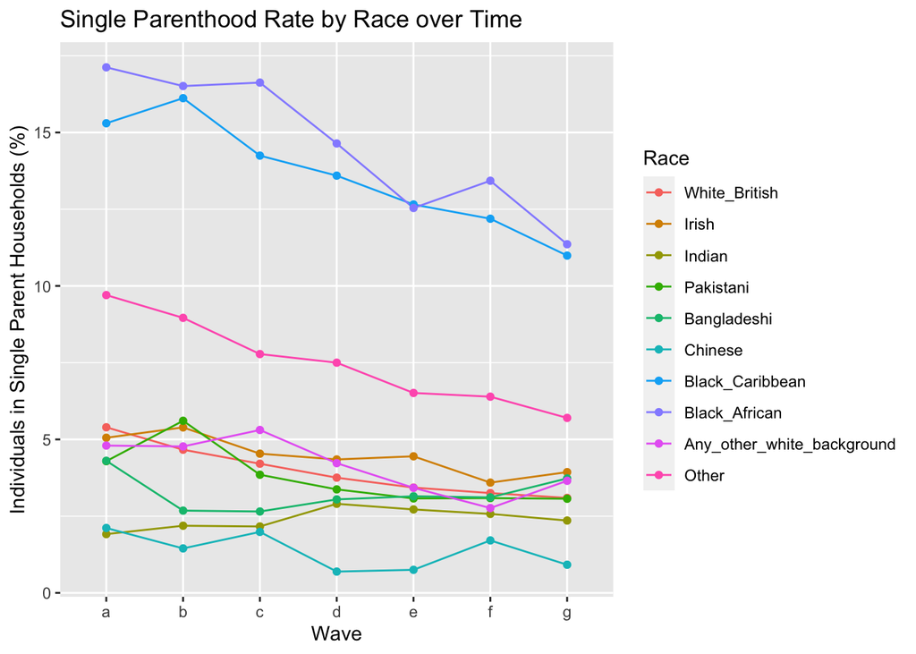

This graph demonstrates both that the pattern of single-parenthood rates in Black-Caribbean and Black-African people are consistently higher than for the other races in this survey and that Black-African people and Black-Caribbean people are very similar in their single-parenthood rate. The graph also shows Black people have been trending towards the other ethnicities in recent waves.

Black-Caribbean people and Black-African people are near identical in the rates. For this reason the data is then amalgamated so that Black-Caribbean and Black-African people are the same value, Black. Though it is interesting that Black-Africans and Black-Caribbeans are so similar in single-parenthood rates when Black-Africans are much more likely to be first generation immigrants to the UK than Black-Caribbean people, as is shown in the table below. This is a substantial socio-economic difference between Africans and Caribbeans as well as a similarity between Africans and the other ethnicities.

```
##                            ukborn uk_born born_abroad    Sum
## race
## White_British                       97.58        2.42 100.00
## Irish                               63.75       36.25 100.00
## Indian                              29.55       70.45 100.00
## Pakistani                           37.91       62.09 100.00
## Bangladeshi                         27.68       72.32 100.00
## Chinese                             15.41       84.59 100.00
## Black_Caribbean                     48.77       51.23 100.00
## Black_African                       13.48       86.52 100.00
## Any_other_white_background          10.72       89.28 100.00
## Other                               36.34       63.66 100.00
```

After noticing this substantial difference within the Black population, I wanted to explore the relationship between immigration status and likelihood to live in a single-parent household. This is a particularly interesting relationship to establish because there’s little research on this correlation in Britain, despite the fact that single parenthood is reported to be more common in Black and Minority Ethnic people [Rabindrakumar 2018:4]. Hence if single parenthood is believed to be more common in minorities, it could easily be the same case for immigrants. However, I hypothesise that immigration status has no substantial impact on the single parenthood rate because if being an immigrant made a person significantly more or less likely to live in a single parent household, then this would be reflected in a difference between African and Caribbean people.

Below are two bar charts examining the proportion of people who live in each household type depending on their immigration status. It must be noted however that the sample size of these graph is very limited compared to the previous graph because the dataset only contains information on immigration status for the first wave of the dataset (wave a).

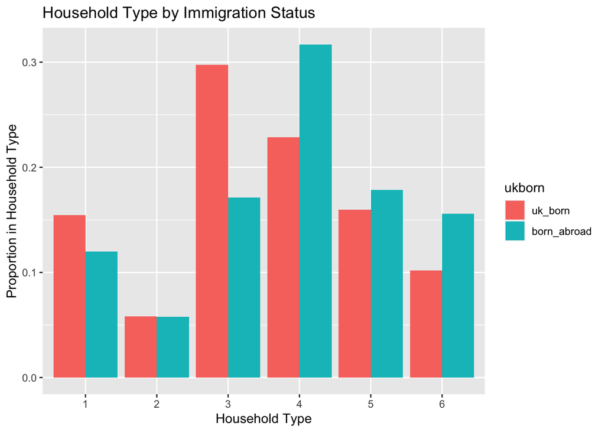

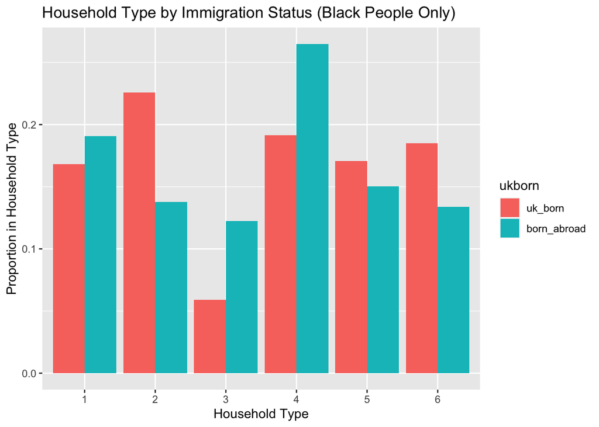

The first graph shows that in the dataset which includes all ethnicities, immigrants and native born individuals are equally likely to live in single parent households. The second graph then shows that UK born Black people are significantly more likely to live in single parent households than Black immigrants. These graphs seem to verify my hypothesis that immigration status doesn’t effect the likelihood of a person to live in a single parent household. However the case appears different among Black people, possibly because immigrants are more likely to live in traditional family structures with 2+ adults per house. It could be the case that both among Black people and everyone else, being an immigrant entails different socio-economic conditions, some of which are amenable to single parenthood and others not.

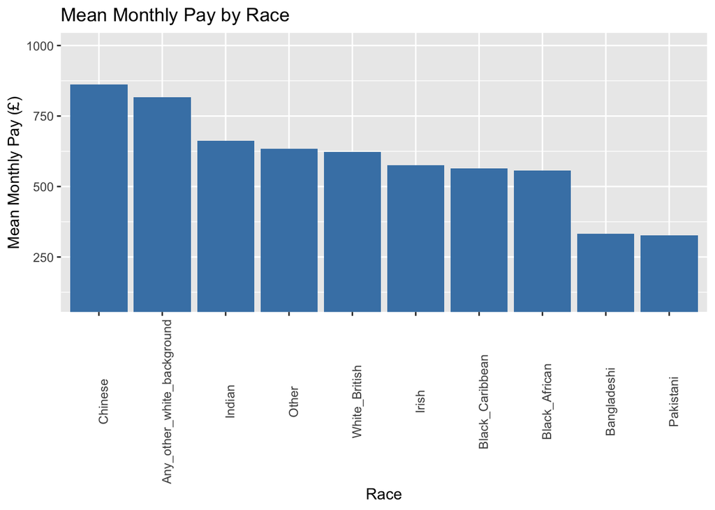

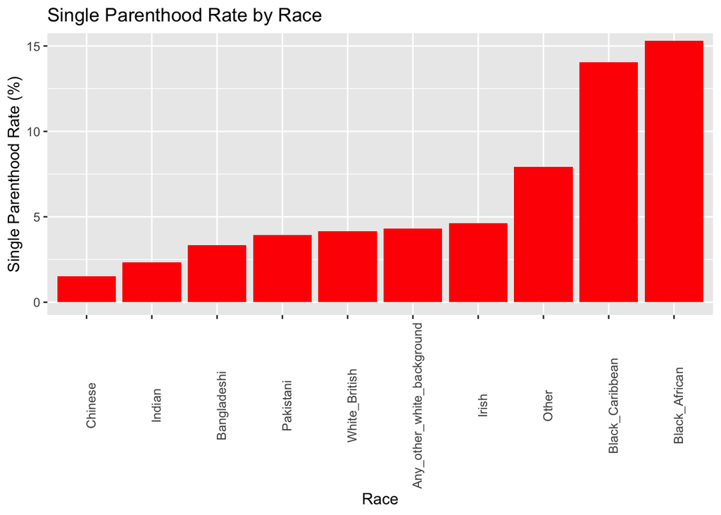

These graphs show that we cannot say that Black people are more likely to live in single parent households because they have a lower income. While Black-Caribbean and Black-African people are the 4th and 3rd lowest paid ethnicities in the dataset respectively, they’re monthly pay isn’t very different from Indian, Other, White-British and Irish people.

The total lack of correlation may be due to the fact that poverty in single parent households is and only can be measured after expenses as opposed to by monthly pay. Hence a correlation may exist between household wealth and the single parenthood rate but not between monthly pay and the single parenthood rate. Wealth probably would have a close correlation with the single parenthood rate as people who live in single parent households have less disposable wealth than single people and people who live in larger families. But to point out that single parents are on average poorer after paying their expenses due to their reliance on a single adults income would be quite redundant. This, essay is about examining the causes of single parenthood not its effects. Furthermore, the lack of a negative correlation between the single parenthood rate and monthly pay is a positive indication that both single parents and young people who live in single parent households have similar access to decent paying jobs as people who don’t live in single parent households. Gingerbread concur that the current record levels of employment in single parents is encouraging [Rabindrakumar 2018:6] and that the next target for Government should be to help single parents struggling with in-work povety. But we can conclude that low pay is not a cause of single parenthood.